## omar gonzáles díaz

Data Analyst and R Programmer

# Ecommerce Perú: análisis de la sección televisores de los 3 ecommerce más importantes del país al 2017

omar gonzáles díaz

30 de marzo de 2017

# Principales Ecommerce del Perú - Análisis descriptivo

La idea de realizar esta investigación fue conocer las estrategias de los principales ecommerece peruanos a través de los productos que ofrecen en sus respectivos sitios web.

Esta es una investigación descriptiva. Lo que queremos es mostrar los datos que encontramos e inferir algunos comentarios que se pueden observar. No es el objetivo de esta entrada analizar a profundidad el por qué de cada una de las estrategias de marketing de cada empresa; por el contrario, mencionaremos algunos datos resaltantes que se observan en los 3 ecommerce más importantes del país: Linio, Ripley y Falabella.

Para este análisis se utilizó el lenguaje de programación “R” para extraer los datos de cada uno de los ecommerce. El código completo lo encontrarán al final, en caso quisieran reproducir los resultados mostrados en esta entrada.

## Sobre los datos

Para obtener los datos ingresamos a las sección de televisores de los 3 ecommerce estudiados. Toda página web tiene una estructura HTML que debe respestar, y con la cuál debe ser consistente. Aprovechando estas 2 características es que podemos programar scripts que, en base a la estructura de cada Ecommerce recoja los siguientes datos de cada uno de los televisores publicitados: a) Marca, b) Nombre del producto, c) Precio actual y d) Precio antes.

Para este proposito se utilizó el paquete [RSelenium](https://cran.r-project.org/web/packages/RSelenium/index.html). Este paquete utiliza el web drive [Selenium 2.0](https://seleniumhq.github.io/docs/wd.html) para automatizar la navegación en un navegador web como Chrome o Firefox.

**Estos son los enlaces a las secciones de televisores de cada uno de los ecommerce estudiados:**

[Linio](https://www.linio.com.pe/c/tv-y-video/televisores)

[Falabella](http://www.falabella.com.pe/falabella-pe/category/cat1450502/Smart-TV?navAction=push)

[Ripley](http://www.ripley.com.pe/ripley-peru/tv-todas)

*Por ahora, solo colocaré el script para descargar los datos desde DropBox, y generar todos los gráficos. Los scripts para extraer la data directamente de los ecommerce los colocaré en las próximas semanas.

## TVs por Ecommerce

Observamos que la tendencia entre los 3 ecommerce es la misma que el año 2016: Linio es el ecommerce con más televisores, seguido por Ripley, y finalmente Falabella. Los 3 ecommerce incrementaron la cantidad de TVs ofertadas este 2017, siendo Linio el ecommerce que incrementó más esta cantidad (+140%).

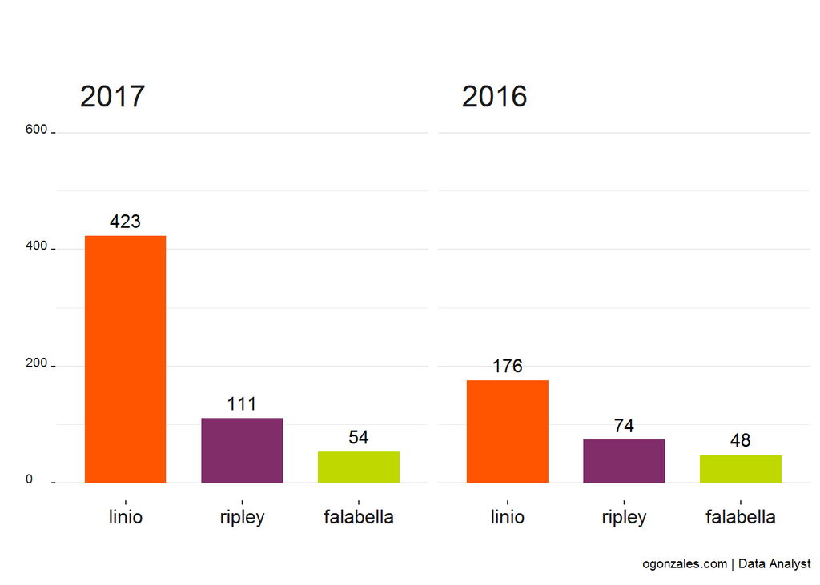

| periodo | ecommerce | cantidad | diferencia.porcentual |
| --- | --- | --- | --- |
| 2016 | falabella | 48 | 0.0% |
| 2016 | linio | 176 | 0.0% |
| 2016 | ripley | 74 | 0.0% |
| 2017 | falabella | 54 | 12.5% |
| 2017 | linio | 423 | 140.3% |
| 2017 | ripley | 111 | 50.0% |

## Pulgadas vs Precio

Scaterplot que muestra la tendencia entre pulgadas vs precio.

**2016:** este año se vio una tendencia clara en los 3 ecommerce, el límite en pulgadas para todos los ecomerce, de cualquier marca, era 65 pulgadas. Solo se observan 4 excepciones, 2 en falabella y 2 en linio; se trata de televisores de 75 pulgadas.

**2017:** si bien aún parece que los 3 ecommerce optan por contar con varios Tvs de 65 pulgada, se observa una mayor oferta de TVs de mayor tamaño, principalmente de 75 y 86 pulgadas.

[interactive chart not shown]

## TVs por Rango de Precio

Es interesante observar que la variedad de televisores ofertados se encuentran entre los S/.500 y S/.1,500 soles.

También encontramos una buena cantidad de televisores en el rango “> S/.4000”.

[interactive chart not shown]

## Distribución de precios por ecommerce

Si nos fijamos en la distribución de precios, notamos que Linio concentra sus precios entre los S/.890 y S/.2,299, con un promedio de S/.1,469. Existe una gran cantidad de TVs cuyos precios son considerados como *outliers*.

En Ripley sucede algo similar encontramos que los precios se centran entre los S/.1,024 y los S/.3,999, siendo el promedio: S/.1,899. Así como varios televisores con precios considerados como *outliers*.

En Falabella notamos que los precios se encuentran entre los S/.5,999 y los S/.1,699, con un promedio de S/.2,949.

Nota: en el comparativo con el año pasado, notamos que la cantidad de *outliers* se ha incrementado notoriamente tanto en Linio como en Ripley. Esto no sucede en Falabella que se mantiene con 3 televisores con precios considerados como *outliers*.

[interactive chart not shown]

## Variedad de marcas de TV según rango de precios

### Ripley

También que en los rangos de precios más elevados *de S/.2,500 a S/.3,500, de S/.3,500 a S/.4,500, y > S/.4,500* la varidad de marcas a disminuido: el 2017 ya no encontramos productos de las marcas Sharp ni Panasonic en estos rangos.

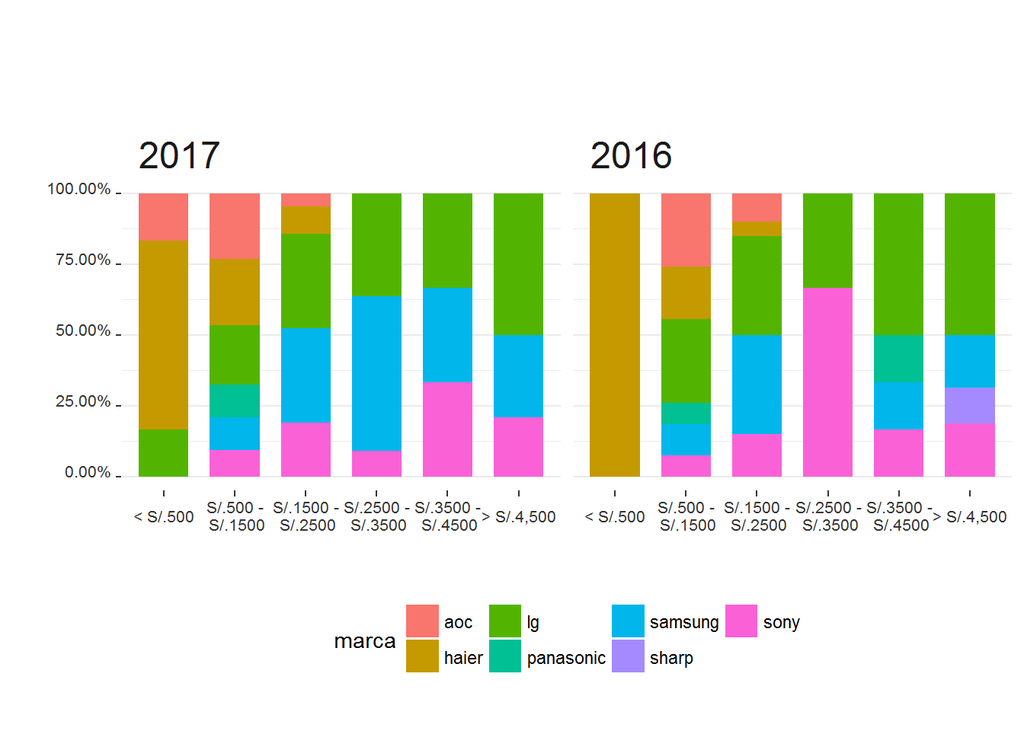

### Falabella

Falabella está ofreciendo más televisores de la marca *samsung* en el rango más alto (“> S/.4,000”). El año pasado era *lg* la marca que domniba esta categoría.

Este ecommerce no ofrece productos de menos de S/.500 soles.

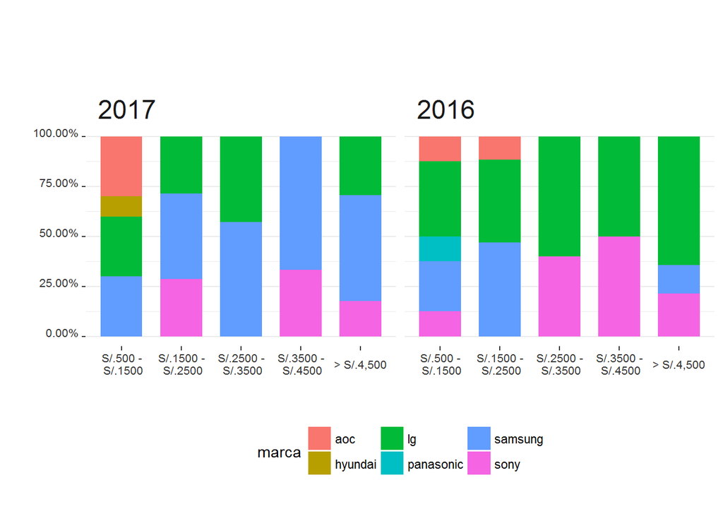

### Linio

Linio es el ecommerce con mayor variedad de marcas en cada uno de los rangos de precios.

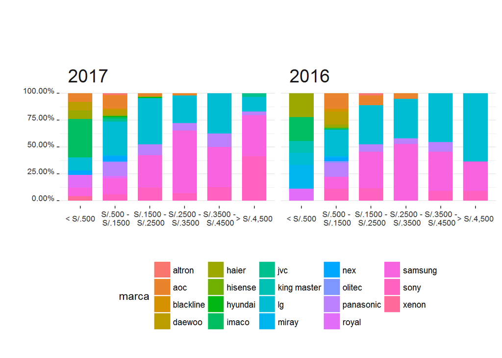

## Precio actual por marca de TV

Estos son las marcas que muestran una gran variedad de precios en los 3 ecommerce: *lg*, *samsung* y *sony*, esto podría deberse a la variedad de televisores tanto a nivel de tamaño como de tecnología.

### Ripley: distribución de precios por marca

[interactive chart not shown]

### Falabella: distribución de precios por marca

[interactive chart not shown]

### Linio: distribución de precios por marca (parte 1 y 2)

[interactive chart not shown]

# Conclusiones:

Me resultó muy interesante el 2016, y lo volví a confirmar este 2017, la perspectiva de negocio de Linio. Este ecommerce, nacido netamente en el espacio digital es el que más variedad de productos ofrece.

Este proyecto me permitió trabajar ciertas técnicas de extracción de datos. Me pareció súper interesante la cantidad de datos que están disponibles en la web, de los cuáles podemos obtener información valiosa con las herramientas adecuadas. Lograrlo costó un poco, pero con los librerías de `R` esta tarea se facilitó mucho; especialmente con `RSelenium`, `Gggplot2` y `Plotly`.

Por otro lado Ripley y Falabella tienen un set de televisores a ofertar, es como si aún en un ecommerce cuidaran el $m^2$ digital.

Agradezco sus comentarios y sugerencias,

Omar G.

```r
############################################
### Total TVS 2017 vs 2016 por Ecommerce ###
############################################


library(dplyr)
library(ggplot2)
library(hrbrthemes)
library(scales)
library(plotly)
library(repmis)
library(knitr)
library(formattable)



### Data alojada en DropBox




tvs <- source_data("https://www.dropbox.com/s/6arewitgenhwwba/2017-03-15-total-tvs.csv?raw=1")




### Hay productos, principalmente en Linio, que no son televisores, pero están en esta sección. Hay que remover estos items.




tvs <- tvs %>%
  filter(pulgadas < 90, !is.na(marca))


###



tvs.cantidad <- tvs  %>%
  group_by(periodo, ecommerce) %>%
  summarise(cantidad = length(marca))



tvs.cantidad <- tvs.cantidad %>% group_by(ecommerce) %>%
  mutate(diferencia.porcentual = (cantidad - lag(cantidad))/lag(cantidad) * 100) %>%
  mutate(diferencia.porcentual = round(diferencia.porcentual,2))


tvs.cantidad[is.na(tvs.cantidad)] <- 0




tvs.cantidad <- tvs.cantidad %>%
  mutate(diferencia.porcentual = percent(paste0(diferencia.porcentual,"%")))







tvs.cantidad$ecommerce <- factor(tvs.cantidad$ecommerce, levels = c("linio",
                                                                    "ripley",
                                                                    "falabella"),
                                 ordered = T)







tvs.cantidad$periodo <- factor(tvs.cantidad$periodo, levels = c(2017,2016),
                               ordered = T)








### Comparativo año a año de la cantidad de TVs en cada Ecommerce



tt1 <- ""
stt1 <- ""
cptn <- "\nogonzales.com | Data Analyst"




ggplot(tvs.cantidad, aes(x=ecommerce, y= cantidad, fill = ecommerce)) +
  geom_bar(stat = "identity", width = .7) +
  facet_grid(~ periodo) +
  theme_bw() +
  scale_fill_manual("ecommerce",
                    values = c("linio" = "#FF5500","ripley" = "#802D69","falabella" = "#BED800")) +
  labs(title = "Ecommerce con más TVs\n",
       x = "", y = "") +
  #theme_ipsum_rc(grid = "Y") +
  theme(axis.text.x = element_text(colour="grey10",size=12,hjust=.5,vjust=.5,face="plain"),
        axis.text.y = element_text(colour="grey10",size=8,hjust=0,vjust=0,face="plain"),
        axis.title.x = element_text(colour="grey40",size=6,angle=0,hjust=.5,vjust=0,face="plain"),
        axis.title.y = element_text(colour="grey40",size=6,angle=90,hjust=.5,vjust=.5,face="plain"),
        plot.title = element_text(size = 24,vjust=2,face="bold"),
        plot.subtitle = element_text(vjust=2, size = 16),
        plot.caption = element_text(vjust=2, size = 8),
        panel.border = element_rect(colour = "white"),
        legend.position = "none",
        strip.text = element_text(size = 18, hjust = 0.08, vjust = -0.5),
        strip.background = element_rect(colour = "white", fill = "white"),
        panel.grid.major.x = element_blank(),
        panel.grid.minor.x = element_blank()) +
  geom_text(aes(label=cantidad), vjust=-0.6, size = 4) +
  ylim(0, 600) +
  labs(title = tt1, subtitle = stt1, caption = cptn,
       x = "", y = "")




### Tabla con dif porcentual año a año



formattable(tvs.cantidad, list(
  diferencia.porcentual = color_tile("white", "green3")))





################################################
####### Scaterplot Pulgadas vs Precios #########
################################################



tv.pulgadas.vs.pulgadas <- tvs %>%
  group_by(periodo, ecommerce, marca, pulgadas) %>%
  filter(pulgadas <= 90, marca != "xenon")




tv.pulgadas.vs.pulgadas$periodo <- factor(tv.pulgadas.vs.pulgadas$periodo, levels = c(2017,2016), ordered = T)

tv.pulgadas.vs.pulgadas$marca <- as.factor(tv.pulgadas.vs.pulgadas$marca)


pulgadas_precio <- ggplot(tv.pulgadas.vs.pulgadas, aes(x = pulgadas, y = precio.actual)) +
  geom_point(aes(color=marca),size = 2,alpha = 0.4) +
  facet_grid(ecommerce ~ periodo, switch = "y") +
  theme_bw() +
  theme(axis.text.x = element_text(colour="grey10",size=10,hjust=.5,vjust=.5,face="plain"),
        axis.text.y=element_blank(),axis.ticks=element_blank(),
        axis.title.x = element_text(colour="grey40",size=12,angle=0,hjust=.5,vjust=0,face="plain"),
        axis.title.y = element_text(colour="grey40",size=12,angle=90,hjust=.5,vjust=.5,face="plain"),
        legend.position = "none",
        plot.title = element_text(size = 24,vjust=4, face="bold"),
        plot.subtitle = element_text(vjust=2, size = 8),
        plot.caption = element_text(vjust=2, size = 8),
        legend.title = element_text(colour="grey40",size=14,hjust=.5,vjust=.5,face="bold"),
        legend.text = element_text(colour="grey10", size=18, face="plain"),
        panel.border = element_rect(colour = "white"),
        strip.text = element_text(size = 12, hjust = 0.05, vjust = -0.5),
        strip.background = element_rect(colour = "white", fill = "white"),
        panel.grid.major.x = element_blank(),
        panel.grid.minor.x = element_blank()) +
  scale_y_continuous(label=comma, limits = c(0,36000)) +
  #scale_x_continuous(label=comma, limits = c(0,100)) +
  labs(title = "", subtitle = "", caption = "",
       x = "pulgadas \n", y = "Precio en S/.")


ggplotly(pulgadas_precio)







############################################
### TVS 2017 vs 2016 por Rango de Precio ###
############################################




tvs.rango <- tvs %>%
  group_by(periodo, ecommerce, rango) %>%
  summarise(cantidad = length(rango))




tvs.rango$periodo <- factor(tvs.rango$periodo, levels = c(2017,2016),
                            ordered = T)



tvs.rango$ecommerce <- factor(tvs.rango$ecommerce, levels = c("linio",
                                                              "ripley",
                                                              "falabella"),
                              ordered = T)





tvs.rango$rango <- factor(tvs.rango$rango, levels = c("< S/.500",
                                                      "S/.500 -\r\n S/.1500",
                                                      "S/.1500 -\r\n S/.2500",
                                                      "S/.2500 -\r\n S/.3500",
                                                      "S/.3500 -\r\n S/.4500",
                                                      "> S/.4,500"),
                          ordered = T)
```

```r
### No usar título porque no entra en los límites del formato de la página web.


tt2 <- ""
stt2 <- "\n"



ggplotly(ggplot(tvs.rango, aes(x = rango, y = cantidad, fill = ecommerce)) +
           geom_bar(stat = "identity") +
           scale_fill_manual("ecommerce",
                             values = c("linio" = "#FF5500","ripley" = "#802D69","falabella" = "#BED800")) +
           facet_grid(~ periodo) +
           theme_bw() +
           coord_flip() +
           #theme_ipsum_rc(grid = "X") +
           theme(axis.text.x = element_text(colour="grey10",size=10,hjust=.5,vjust=.5,face="plain"),
                 axis.text.y = element_text(colour="grey10",size=10,hjust=1,vjust=0,face="plain"),
                 axis.title.x = element_text(colour="grey40",size=16,angle=0,hjust=.5,vjust=0,face="plain"),
                 axis.title.y = element_text(colour="grey40",size=16,angle=90,hjust=.5,vjust=.5,face="plain"),
                 plot.title = element_text(size = 24,vjust=4, face="bold"),
                 plot.subtitle = element_text(vjust=2, size = 16),
                 plot.caption = element_text(vjust=2, size = 16),
                 panel.border = element_rect(colour = "white"),
                 legend.position = "none",
                 strip.text = element_text(size = 18, hjust = 0.01, vjust = -0.5),
                 strip.background = element_rect(colour = "white", fill = "white"),
                 panel.grid.major.y = element_blank(),
                 panel.grid.minor.y = element_blank()) +
           #geom_text(aes(label=cantidad), hjust=-0.25, size = 4) +
           ylim(0, 300) +
           labs(title = tt2, subtitle = stt2, caption = cptn,
                x = "", y = ""))





###############################################
#### Distribución de precios por Ecommerce ####
###############################################



tvs.precios <- tvs






tvs.precios$periodo <- factor(tvs.precios$periodo, levels = c(2017,2016),
                              ordered = T)



tvs.precios$ecommerce <- factor(tvs.precios$ecommerce, levels = rev(c("linio","ripley","falabella")),
                                ordered = T)




### Gráfico


p <- plot_ly(tvs.precios, x = ~periodo, y = ~precio.actual, color = ~ecommerce,colors = c("#BED800", "#802D69", "#FF5500"), type = "box") %>%
  layout(boxmode = "group")

p







#############################################
### Gráficos individuales por ecommerce ###
#############################################



### ripley ###


tvs.ripley <- tvs[tvs$ecommerce == "ripley",]


### falabella ###

tvs.falabella <- tvs[tvs$ecommerce == "falabella",]


### linio ###

tvs.linio <- tvs[tvs$ecommerce == "linio",]



tvs.linio.parte1 <- tvs.linio %>%
  filter(marca %in% c("lg", "aoc","imaco",
                      "royal","panasonic",
                      "samsung", "sony", "olitec",
                      "haier", "nex"))




tvs.linio.parte2 <- tvs.linio %>%
  filter(marca %in% c("daywoo","altron","blackline",
                      "miray","hisense", "king master",
                      "xenon", "hyundai", "jvc"))









#########################################################
### MARCAS DE TV POR RANGO DE PRECIO - EN PORCENTAJES ###
#########################################################




### Ripley



tvs.ripley.tvs.por.rango <- tvs.ripley  %>%
  group_by(periodo, rango, marca) %>%
  summarise(cantidad.marca = length(marca)) %>%
  #mutate(porcentaje = paste0(round(cantidad.marca/sum(cantidad.marca)*100,2),'%'))
  mutate(porcentaje_tvs = round(cantidad.marca/sum(cantidad.marca),4))






tvs.ripley.tvs.por.rango$periodo <- factor(tvs.ripley.tvs.por.rango$periodo, levels = c(2017,2016),
                                           ordered = T)







tvs.ripley.tvs.por.rango$rango <- factor(tvs.ripley.tvs.por.rango$rango, levels = c("< S/.500",
                                                                                    "S/.500 -\r\n S/.1500",
                                                                                    "S/.1500 -\r\n S/.2500",
                                                                                    "S/.2500 -\r\n S/.3500",
                                                                                    "S/.3500 -\r\n S/.4500",
                                                                                    "> S/.4,500"),
                                         ordered = T)






#tt3 <- "Ripley.com.pe \nmarcas de tvs por rango de precio en porcentajes %"
tt3 <- ""
stt3 <- "\n"






ggplot(tvs.ripley.tvs.por.rango, aes(x=rango, y= porcentaje_tvs ,fill=marca)) +
  geom_bar(stat = "identity", width = .7) +
  facet_grid(~ periodo) +
  theme_bw() +
  theme(axis.text.x = element_text(colour="grey20",size=8,hjust=.5,vjust=.5,face="plain"),
        axis.text.y = element_text(colour="grey20",size=8,hjust=1,vjust=0,face="plain"),
        axis.title.x = element_text(colour="grey20",size=18,angle=0,hjust=.5,vjust=0,face="plain"),
        axis.title.y = element_text(colour="grey20",size=16,angle=90,hjust=.5,vjust=.5,face="plain"),
        plot.title = element_text(vjust=2, size = 24,face="bold"),
        plot.subtitle = element_text(vjust=2, size = 16),
        plot.caption = element_text(vjust=2, size = 16),
        legend.position = "bottom",
        panel.border = element_rect(colour = "white"),
        strip.text = element_text(size = 18, hjust = 0.05, vjust = -0.5),
        strip.background = element_rect(colour = "white", fill = "white"),
        panel.grid.major.x = element_blank(),
        panel.grid.minor.x = element_blank()) +
  scale_y_continuous(labels=percent) +
  # scale_fill_manual(
  #   values = c("hisense" = "#F39EF7","sony" = "#003366","panasonic" = "#FCB462",
  #              "samsung" = "#7ec0ee", "lg" = "#A21420",
  #              "aoc" = "#9DCC27", "sharp" = "#BEBBDA", "hyundai" = "#FCB442")) +
  # labs(title = tt5, subtitle = stt5, caption = cptn,
  #      x = "", y = "") +
  labs(title = tt3, subtitle = stt3, caption = "",
       x = "", y = "")
```

```r
### Falabella



tvs.falabella.tvs.por.rango <- tvs.falabella  %>%
  group_by(periodo, rango, marca) %>%
  summarise(cantidad.marca = length(marca)) %>%
  #mutate(porcentaje = paste0(round(cantidad.marca/sum(cantidad.marca)*100,2),'%'))
  mutate(porcentaje_tvs = round(cantidad.marca/sum(cantidad.marca),4))





tvs.falabella.tvs.por.rango$periodo <- factor(tvs.falabella.tvs.por.rango$periodo, levels = c(2017,2016),
                                              ordered = T)



tvs.falabella.tvs.por.rango$rango <- factor(tvs.falabella.tvs.por.rango$rango, levels = c("< S/.500",
                                                                                          "S/.500 -\r\n S/.1500",
                                                                                          "S/.1500 -\r\n S/.2500",
                                                                                          "S/.2500 -\r\n S/.3500",
                                                                                          "S/.3500 -\r\n S/.4500",
                                                                                          "> S/.4,500"),
                                            ordered = T)



##tt5 <- "Sagafalabella \n % marcas de tvs por rango de precios"

tt5 <- ""
stt5 <- "\n"



ggplot(tvs.falabella.tvs.por.rango, aes(x=rango, y= porcentaje_tvs ,fill=marca)) +
  geom_bar(stat = "identity", width = .7) +
  facet_grid(~ periodo) +
  theme_bw() +
  #theme_ipsum_rc(grid = "Y") +
  theme(axis.text.x = element_text(colour="grey20",size=8,hjust=.5,vjust=.5,face="plain"),
        axis.text.y = element_text(colour="grey20",size=8,hjust=1,vjust=0,face="plain"),
        axis.title.x = element_text(colour="grey20",size=18,angle=0,hjust=.5,vjust=0,face="plain"),
        axis.title.y = element_text(colour="grey20",size=16,angle=90,hjust=.5,vjust=.5,face="plain"),
        plot.title = element_text(vjust=2, size = 24,face="bold"),
        plot.subtitle = element_text(vjust=2, size = 16),
        plot.caption = element_text(vjust=2, size = 16),
        legend.position = "bottom",
        panel.border = element_rect(colour = "white"),
        strip.text = element_text(size = 18, hjust = 0.05, vjust = -0.5),
        strip.background = element_rect(colour = "white", fill = "white"),
        panel.grid.major.x = element_blank(),
        panel.grid.minor.x = element_blank()) +
  scale_y_continuous(labels=percent) +
  # scale_fill_manual(
  #   values = c("hisense" = "#F39EF7","sony" = "#003366","panasonic" = "#FCB462",
  #              "samsung" = "#7ec0ee", "lg" = "#A21420",
  #              "aoc" = "#9DCC27", "sharp" = "#BEBBDA", "hyundai" = "#FCB442")) +
  # labs(title = tt5, subtitle = stt5, caption = cptn,
  #      x = "", y = "") +
  labs(title = tt5, subtitle = stt5, caption = "",
       x = "", y = "")




### Linio




tvs.linio.tvs.por.rango <- tvs.linio  %>%
  group_by(periodo, rango, marca) %>%
  summarise(cantidad.marca = length(marca)) %>%
  #mutate(porcentaje = paste0(round(cantidad.marca/sum(cantidad.marca)*100,2),'%'))
  mutate(porcentaje_tvs = round(cantidad.marca/sum(cantidad.marca),4))








tvs.linio.tvs.por.rango$periodo <- factor(tvs.linio.tvs.por.rango$periodo, levels = c(2017,2016),
                                          ordered = T)




tvs.linio.tvs.por.rango$rango <- factor(tvs.linio.tvs.por.rango$rango, levels = c("< S/.500",
                                                                                  "S/.500 -\r\n S/.1500",
                                                                                  "S/.1500 -\r\n S/.2500",
                                                                                  "S/.2500 -\r\n S/.3500",
                                                                                  "S/.3500 -\r\n S/.4500",
                                                                                  "> S/.4,500"),
                                        ordered = T)




#tt5 <- "Linio \n % marcas de tvs por rango de precios"
tt5 <- ""

stt5 <- "\n"



ggplot(tvs.linio.tvs.por.rango, aes(x=rango, y= porcentaje_tvs ,fill=marca)) +
  geom_bar(stat = "identity", width = .7) +
  facet_grid(~ periodo) +
  theme_bw() +
  #theme_ipsum_rc(grid = "Y") +
  theme(axis.text.x = element_text(colour="grey20",size=8,hjust=.5,vjust=.5,face="plain"),
        axis.text.y = element_text(colour="grey20",size=8,hjust=1,vjust=0,face="plain"),
        axis.title.x = element_text(colour="grey20",size=18,angle=0,hjust=.5,vjust=0,face="plain"),
        axis.title.y = element_text(colour="grey20",size=16,angle=90,hjust=.5,vjust=.5,face="plain"),
        plot.title = element_text(vjust=2, size = 24,face="bold"),
        plot.subtitle = element_text(vjust=2, size = 16),
        plot.caption = element_text(vjust=2, size = 16),
        legend.position = "bottom",
        panel.border = element_rect(colour = "white"),
        strip.text = element_text(size = 18, hjust = 0.05, vjust = -0.5),
        strip.background = element_rect(colour = "white", fill = "white"),
        panel.grid.major.x = element_blank(),
        panel.grid.minor.x = element_blank()) +
  scale_y_continuous(labels=percent) +
  # scale_fill_manual(
  #   values = c("hisense" = "#F39EF7","sony" = "#003366","panasonic" = "#FCB462",
  #              "samsung" = "#7ec0ee", "lg" = "#A21420",
  #              "aoc" = "#9DCC27", "sharp" = "#BEBBDA", "hyundai" = "#FCB442")) +
  # labs(title = tt5, subtitle = stt5, caption = cptn,
  #      x = "", y = "") +
  labs(title = tt5, subtitle = stt5, caption = "",
       x = "", y = "")




##################################################
###### Distribución de precios por marca #########
##################################################




### Ripley: distribución de los precios de TVs por marca



tvs.ripley$periodo <- factor(tvs.ripley$periodo, levels = c(2017,2016),
                             ordered = T)





precio.actual.ripley <- plot_ly(tvs.ripley, x = ~periodo, y = ~precio.actual, color = ~marca, type = "box") %>%
  layout(boxmode = "group")
```

```r
precio.actual.ripley





### Falabella: distribución de los precios de TVs por marca



tvs.falabella$periodo <- factor(tvs.falabella$periodo, levels = c(2017,2016),
                                ordered = T)




precio.actual.falabella <- plot_ly(tvs.falabella, x = ~periodo, y = ~precio.actual, color = ~marca, type = "box") %>%
  layout(boxmode = "group")

precio.actual.falabella



### Linio: Distribución de precios por marca
### Precio Actual - Parte 1 y 2


tvs.linio$periodo <- factor(tvs.linio$periodo, levels = c(2017,2016),
                            ordered = T)




tvs.linio.parte1$periodo <- factor(tvs.linio.parte1$periodo, levels = c(2017,2016),
                                   ordered = T)



tvs.linio.parte2$periodo <- factor(tvs.linio.parte2$periodo, levels = c(2017,2016),
                                   ordered = T)





### Parte 1





precio.actual.linio.parte1 <- plot_ly(tvs.linio.parte1, x = ~periodo, y = ~precio.actual, color = ~marca, type = "box") %>%
  layout(boxmode = "group")

precio.actual.linio.parte1


### Parte 2


precio.actual.linio.parte2 <- plot_ly(tvs.linio.parte2, x = ~periodo, y = ~precio.actual, color = ~marca, type = "box") %>%
layout(boxmode = "group")

precio.actual.linio.parte2
```